# 다변량자료분석 HW6

‘수학과 201521139 이재학’

2021-04-28

##### **데이터 불러오기**

```r
library(HSAUR)
library(car)
data(water)
x<-water
head(x)
```

```
##   location       town mortality hardness
## 1    South       Bath      1247      105
## 2    North Birkenhead      1668       17
## 3    South Birmingham      1466        5
## 4    North  Blackburn      1800       14
## 5    North  Blackpool      1609       18
## 6    North     Bolton      1558       10
```

##### **location별로 데이터 나누기**

```r
x_s<-subset(x,location=="South")
x_n<-subset(x,location=="North")
head(x_s)
```

```
##    location        town mortality hardness
## 1     South        Bath      1247      105
## 3     South  Birmingham      1466        5
## 8     South Bournemouth      1299       78
## 10    South    Brighton      1359       84
## 11    South     Bristol      1392       73
## 13    South     Cardiff      1519       21
```

```r
head(x_n)
```

```
##   location       town mortality hardness
## 2    North Birkenhead      1668       17
## 4    North  Blackburn      1800       14
## 5    North  Blackpool      1609       18
## 6    North     Bolton      1558       10
## 7    North     Bootle      1807       15
## 9    North   Bradford      1637       10
```

```r
x_s<-x_s[,3:4]                    #town 지우기
x_n<-x_n[,3:4]
```

##### **등분산성 확인하기**

##### **1.botplot으로 확인**

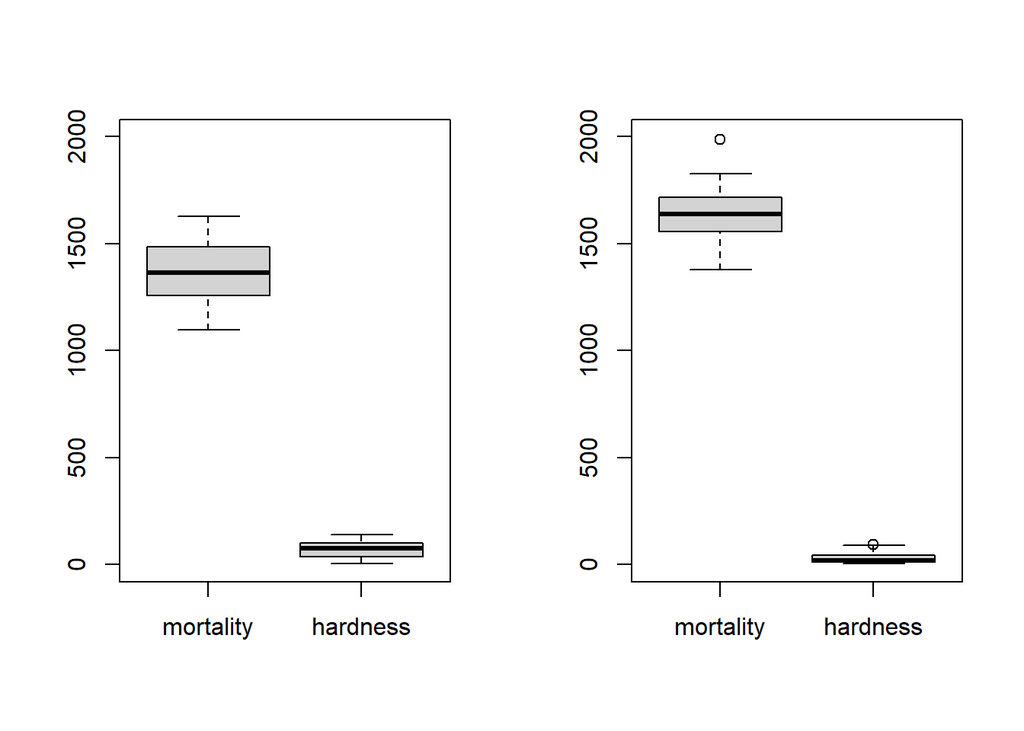

```r
par(mfrow=c(1,2))
boxplot(x_s,ylim=c(0,2000))
boxplot(x_n,ylim=c(0,2000))
```

##### **boxplot으로 scale을 동일하게 봤을때 두 변수 모두 차이가 보인다.**

##### **2.수치로 확인->공분산행렬,상관행렬**

```r
cov(x_s)
```

```
##           mortality  hardness
## mortality 19675.442 -3409.006
## hardness  -3409.006  1628.985
```

```r
cov(x_n)
```

```
##           mortality   hardness
## mortality 18751.718 -1319.1294
## hardness  -1319.129   683.0118
```

```r
cor(x_s)
```

```
##            mortality   hardness
## mortality  1.0000000 -0.6021533
## hardness  -0.6021533  1.0000000
```

```r
cor(x_n)
```

```
##            mortality   hardness
## mortality  1.0000000 -0.3685978
## hardness  -0.3685978  1.0000000
```

##### **수치,스케일링한 수치로 봤을때도 결론 짓기 어렵다.**

#### **3.box m test 확인**

##### **정규성에 대한 가정이 필요하므로 정규성 먼저 확인**

##### **location에 따른 변수 한개씩**

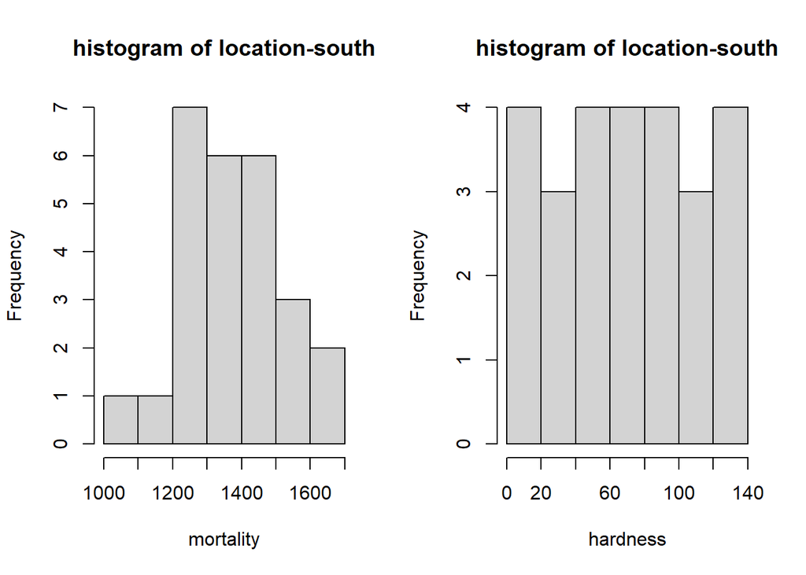

```r
par(mfrow=c(1,2))
hist(x_s[,1],main="histogram of location-south",xlab=colnames(x_s[1]))
hist(x_s[,2],main="histogram of location-south",xlab=colnames(x_s[2]))
```

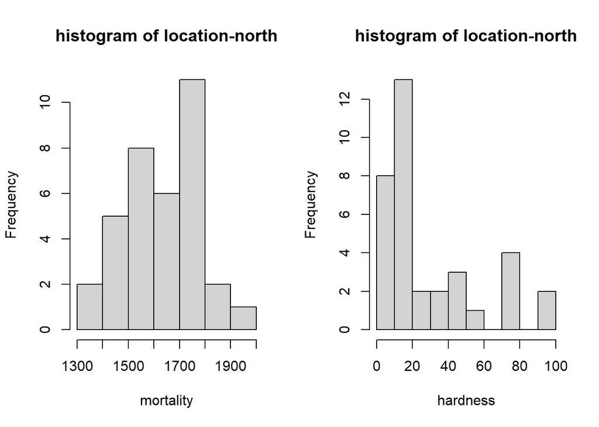

```r
par(mfrow=c(1,2))
hist(x_n[,1],main="histogram of location-north",xlab=colnames(x_n[1]))
hist(x_n[,2],main="histogram of location-north",xlab=colnames(x_n[2]))
```

##### **정규분포의 형태를 띄진 않지만, 표본의 수가 적으므로 단정 지을 수 없다.**

##### **location에 따른 변수 쌍**

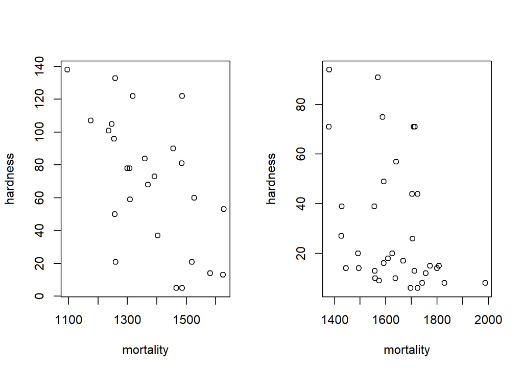

```r
par(mfrow=c(1,2))
plot(x_s)
plot(x_n)
```

##### **변수 하나씩 본것처럼 마찬가지로, 타원의형태를 띄지 않아 정규성을 살펴볼 수 없지만, 표본의 수가 적으므로 단정 지을 수 없다.**

#### **QQplot-2차원 동시고려**

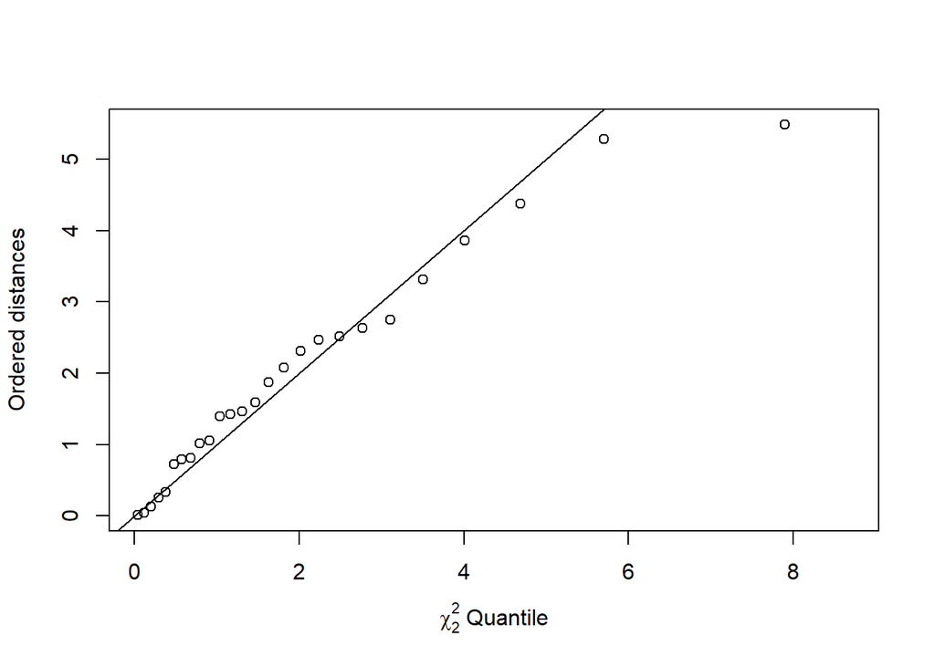

```r
xs<-x_s
xscm<-colMeans(xs)
xss<-cov(xs)
xsd<-function(x){
  t(x-xscm) %*% solve(xss) %*% (x-xscm)
}
xsd<-apply(xs,1,xsd)
xsqc<-qchisq((1:nrow(xs)-1/2)/nrow(xs),df=2)
xssd<-sort(xsd)
plot(xsqc,xssd,xlab=expression(paste(chi[2]^2," Quantile")),ylab="Ordered distances",xlim=range(xsqc)*c(1,1.1))
abline(a=0,b=1)
```

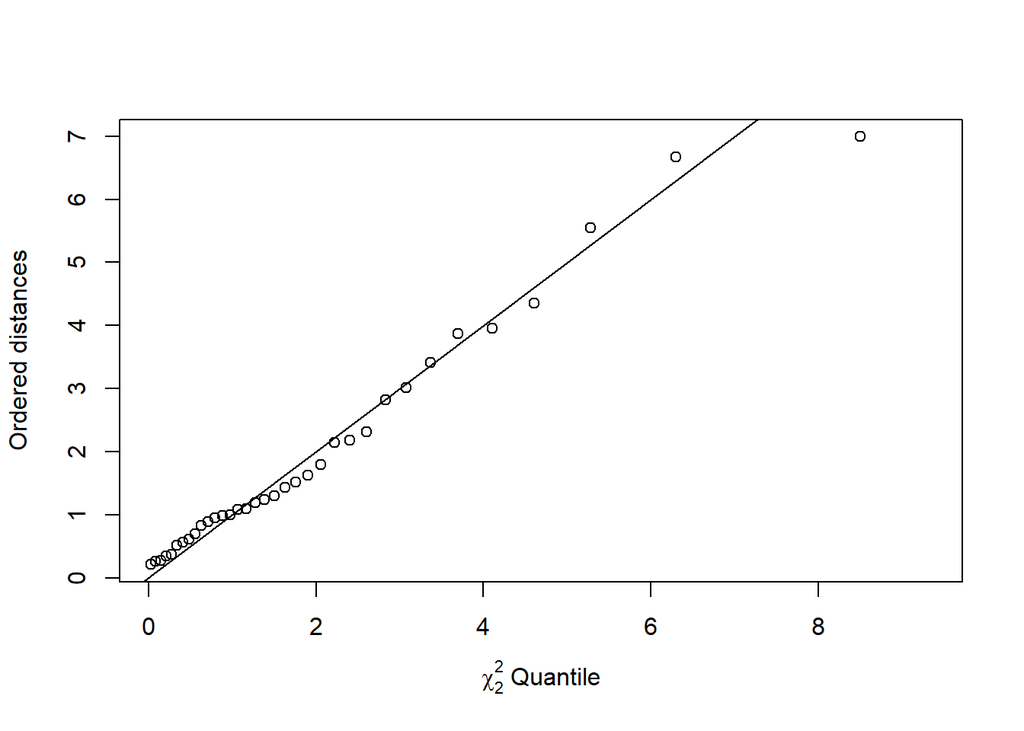

```r
xn<-x_n
xncm<-colMeans(xn)
xns<-cov(xn)
xnd<-function(x){
  t(x-xncm) %*% solve(xns) %*% (x-xncm)
}
xnd<-apply(xn,1,xnd)
xnqc<-qchisq((1:nrow(xn)-1/2)/nrow(xn),df=2)
xnsd<-sort(xnd)
plot(xnqc,xnsd,xlab=expression(paste(chi[2]^2," Quantile")),ylab="Ordered distances",xlim=range(xnqc)*c(1,1.1))
abline(a=0,b=1)
```

##### **2차원 변수를 고려하여 qqplot을 그려본 경우, outlier 하나씩을 제외하고는 정규분포를 따른다고 가정할 수 있다.따라서, box m test 를 사용하여 common variance를 살펴보자.**

#### **box m test**

```r
library(biotools)
x<-x[,-2]                       #town 제거
boxM(x[,-1],group=x[,1])
```

```
##
##  Box's M-test for Homogeneity of Covariance Matrices
##
## data:  x[, -1]
## Chi-Sq (approx.) = 5.7782, df = 3, p-value = 0.1229
```

##### **p-value가 0.12로 유의수준을 10%로 잡아도 기각할 수없다.따라서 등분산을 가정할 수 있다.**

##### **MANOVA**

```r
attach(x)
summary(Anova(lm(cbind(mortality,hardness)~location,data=x)))
```

```
##
## Type II MANOVA Tests:
##
## Sum of squares and products for error:
##           mortality   hardness
## mortality 1129444.4 -130075.55
## hardness  -130075.6   63947.02
##
## ------------------------------------------
##
## Term: location
##
## Sum of squares and products for the hypothesis:
##           mortality  hardness
## mortality  983729.2 -150817.1
## hardness  -150817.1   23122.0
##
## Multivariate Tests: location
##                  Df test stat approx F num Df den Df     Pr(>F)
## Pillai            1 0.4737437 26.10623      2     58 8.2172e-09 ***
## Wilks             1 0.5262563 26.10623      2     58 8.2172e-09 ***
## Hotelling-Lawley  1 0.9002148 26.10623      2     58 8.2172e-09 ***
## Roy               1 0.9002148 26.10623      2     58 8.2172e-09 ***
## ---
## Signif. codes:  0 '***' 0.001 '**' 0.01 '*' 0.05 '.' 0.1 ' ' 1
```

##### **MANOVA에서 사용하는 4가지의 통계량을 봤을때 p-value가 상당히 낮은 값을 보인다. 따라서 귀무가설을 기각할 수 있고, location에따른 차이를 통계적으로 확인 할 수 있다.**

##### **profile plot**

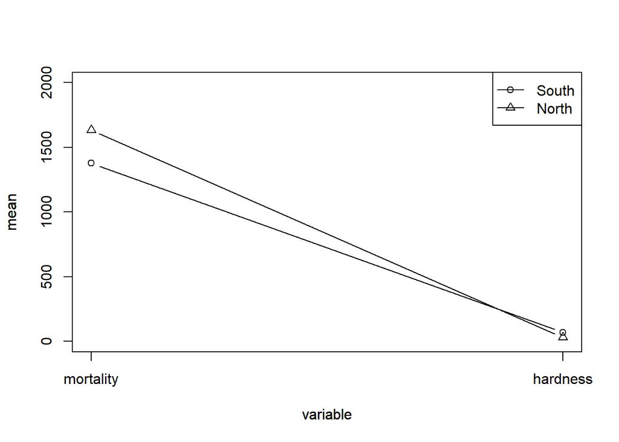

```r
lo1=apply(x[x$location=="South",-1],2,mean)
lo2=apply(x[x$location=="North",-1],2,mean)
plot(lo1,type="b",pch=1,ylim=c(0,2000),ylab="mean",xlab="variable",axes=F);par(new=T)   #덮어서 그래프 그리기
plot(lo2,type="b",pch=2,ylim=c(0,2000),ylab="mean",xlab="variable",axes=F);par(new=T)
legend("topright",c("South","North"),lty=1,pch=c(1,2))
axis(1,at=1:2,lab=c("mortality","hardness"))
axis(2,las=3)
box()
```

##### **scale의 차이가 큼을 고려하면, 두 변수 모두 차이가 큼을 알 수 있다.**

##### **변수 하나씩 ANOVA**

```r
summary(aov(mortality~factor(location),data=x))
```

```
##                  Df  Sum Sq Mean Sq F value  Pr(>F)
## factor(location)  1  983729  983729   51.39 1.4e-09 ***
## Residuals        59 1129444   19143
## ---
## Signif. codes:  0 '***' 0.001 '**' 0.01 '*' 0.05 '.' 0.1 ' ' 1
```

```r
summary(aov(hardness~factor(location),data=x))
```

```
##                  Df Sum Sq Mean Sq F value   Pr(>F)
## factor(location)  1  23122   23122   21.33 2.14e-05 ***
## Residuals        59  63947    1084
## ---
## Signif. codes:  0 '***' 0.001 '**' 0.01 '*' 0.05 '.' 0.1 ' ' 1
```

##### **변수 하나씩 봤을때도 p-value가 상당히 낮으므로, 귀무가설을 기각한다.따라서 차이가 통계적으로 유의하게 있다.**

##### **pairwise.t.test**

```r
pairwise.t.test(mortality,location,p.adjust.method="bonferroni")
```

```
##
##  Pairwise comparisons using t tests with pooled SD
##
## data:  mortality and location
##
##       North
## South 1.4e-09
##
## P value adjustment method: bonferroni
```

```r
pairwise.t.test(hardness,location,p.adjust.method="bonferroni")
```

```
##
##  Pairwise comparisons using t tests with pooled SD
##
## data:  hardness and location
##
##       North
## South 2.1e-05
##
## P value adjustment method: bonferroni
```

```r
t.test(mortality~location,var.equal=TRUE,data=x)
```

```
##
##  Two Sample t-test
##
## data:  mortality by location
## t = 7.1686, df = 59, p-value = 1.402e-09
## alternative hypothesis: true difference in means is not equal to 0
## 95 percent confidence interval:
##  185.1125 328.4721
## sample estimates:
## mean in group North mean in group South
##            1633.600            1376.808
```

```r
t.test(hardness~location,var.equal=TRUE,data=x)
```

```
##
##  Two Sample t-test
##
## data:  hardness by location
## t = -4.6188, df = 59, p-value = 2.14e-05
## alternative hypothesis: true difference in means is not equal to 0
## 95 percent confidence interval:
##  -56.42512 -22.31334
## sample estimates:
## mean in group North mean in group South
##            30.40000            69.76923
```

##### **집단이 두개이므로 한가지의 pair가나오고,등분산을 가정한 t.test와의 결과와도 같음을 확인할 수 있다.두 방법에서 살펴본 p-value가 상당히 작으므로, location 별로 차이가 통계적으로 유의하게 있음을 알 수 있다,**